# RISE Aim 1 - Enrollment

My Vu

11/09/2026

```
## # A tibble: 0 × 1
## # ℹ 1 variable: child_hashed_id <chr>
```

# Demographics

| **Characteristic** | **Overall** N = 55<sup>1</sup> | **6** N = 29<sup>1</sup> | **12** N = 26<sup>1</sup> |
| --- | --- | --- | --- |
| Gender |  |  |  |
| Female | 28 (50.9) | 14 (48.3) | 14 (53.8) |
| Male | 27 (49.1) | 15 (51.7) | 12 (46.2) |
| race |  |  |  |
| American Indian or Alaska Native | 0 (0.0) | 0 (0.0) | 0 (0.0) |
| Asian | 7 (12.7) | 4 (13.8) | 3 (11.5) |
| Black or African American | 1 (1.8) | 1 (3.4) | 0 (0.0) |
| Native Hawaiian or Other Pacific Islander | 1 (1.8) | 1 (3.4) | 0 (0.0) |
| White | 34 (61.8) | 16 (55.2) | 18 (69.2) |
| More than one race | 12 (21.8) | 7 (24.1) | 5 (19.2) |
| Ethnicity |  |  |  |
| Hispanic | 3 (5.5) | 3 (10.3) | 0 (0.0) |
| Not Hisp | 52 (94.5) | 26 (89.7) | 26 (100.0) |
| demographic__education_level2 |  |  |  |
| High school | 1 (1.8) | 0 (0.0) | 1 (3.8) |
| Associate (some college) | 1 (1.8) | 1 (3.4) | 0 (0.0) |
| Bachelor/College | 18 (32.7) | 12 (41.4) | 6 (23.1) |
| Graduate and Professional | 35 (63.6) | 16 (55.2) | 19 (73.1) |
| demographic__annual_income2 |  |  |  |
| < 50,000 | 8 (15.1) | 4 (14.8) | 4 (15.4) |
| 50,000 - 100,000 | 17 (32.1) | 9 (33.3) | 8 (30.8) |
| 101,000 - 200,000 | 21 (39.6) | 12 (44.4) | 9 (34.6) |
| > 200,000 | 7 (13.2) | 2 (7.4) | 5 (19.2) |
| (Missing) | 2 | 2 | 0 |
| Region |  |  |  |
| Northeast | 13 (24.1) | 7 (25.0) | 6 (23.1) |
| Midwest | 17 (31.5) | 12 (42.9) | 5 (19.2) |
| South | 9 (16.7) | 1 (3.6) | 8 (30.8) |
| West | 15 (27.8) | 8 (28.6) | 7 (26.9) |
| (Missing) | 1 | 1 | 0 |

<sup>1</sup> n (%)

MAKE SURE TO REMOVE LONG VIDEOS and TRIM the extra frames

# Geometric Social

Note on how outcome was derive:

1. Remove frames coded as “nobabyface”, “noface”, “none”, or “away”
2. Remove “left”, “right” frames with confidence < 85%
3. Use “left” vs “right” to code “target” vs “non-target” depending on the task and version. Calculate % looking for each social side as:

   % looking = (target) / (target + non-target)

   *left & right frames all need to have >= 85% confidence. A trial must have at least 33% usable data (i.e. left, right frames at 85% confidence) to be included.

## Data count

Number (and percent) of infants who viewed the task at all (2nd column, as % of consented sample with any icatcher data & in frame data , with sufficient usable data (3rd column, as % of infants who viewed the task), with fixation on a single side >80% of the task (4th column, as % of infants with usable data), and final N in the analytic dataset.

```
## # A tibble: 2 × 6
##   Age   Enrolled iCatcher_Ran iCatcher_Good Fixation  Usable
##   <fct> <chr>    <chr>        <chr>         <chr>      <int>
## 1 6     29       29 (100.0%)  28 (96.6%)    5 (17.9%)     23
## 2 12    26       26 (100.0%)  26 (100.0%)   3 (11.5%)     23
```

Video quality metrics by age group. Percentages reflect the mean across trials with iCatcher+ output only, calculated out of frames processed by iCatcher+. Trials where iCatcher+ produced no output are counted as missing trials.

| **Characteristic** | **6** N = 29<sup>1</sup> | **12** N = 26<sup>1</sup> |
| --- | --- | --- |
| max_trial |  |  |
| 10 | 29 (100%) | 26 (100%) |
| No face detected (%) | 0.0 (0.0, 0.0) | 0.0 (0.0, 3.9) |
| Away looks (%) | 2.7 (0.0, 10.0) | 0.8 (0.0, 5.0) |
| Low confidence left & right frames (%) | 9.8 (5.1, 14.8) | 8.8 (6.6, 15.0) |

<sup>1</sup> n (%); Median (Q1, Q3)

**Median (IQR) number of test trials with usable data (final analytic)**

| **Characteristic** | **6** N = 23 | **12** N = 23 |
| --- | --- | --- |
| trial_num |  |  |
| Median (Q1, Q3) | 8.00 (7.00, 9.00) | 7.00 (5.00, 9.00) |
| Min, Max | 3.00, 10.00 | 2.00, 10.00 |

# VPC

8 versions, participants sees both object & face stimuli

Note on how outcome was derive:

1. Remove frames coded as “nobabyface”, “noface”, “none”, or “away”
2. Remove frames with with confidence < 85%
3. Use “left” vs “right” to code “target” vs “non-target” depending on the task and version. Calculate % looking for each novel side as:

   % looking = (target) / (target + non-target)

   *left & right frames all need to have >= 85% confidence. A trial must have at least 33% usable data (i.e. left, right frames at 85% confidence) to be included.

## Data count

Number (and percent) of infants who viewed the task at all (2nd column, as % of consented sample with any icatcher data & in frame data , with sufficient usable data (3rd column, as % of infants who viewed the task), with fixation on a single side >80% of the task (4th column, as % of infants with usable data), and final N in the analytic dataset.

```
## # A tibble: 2 × 6
##   Age   Enrolled iCatcher_Ran iCatcher_Good Fixation Usable
##   <fct> <chr>    <chr>        <chr>         <chr>     <int>
## 1 6     29       29 (100.0%)  27 (93.1%)    2 (7.4%)     25
## 2 12    26       25 (96.2%)   23 (92.0%)    1 (4.3%)     22
```

Video quality metrics by age group. Percentages reflect the mean across trials with iCatcher+ output only, calculated out of frames processed by iCatcher+. Trials where iCatcher+ produced no output are counted as missing trials.

| **Characteristic** | **6** N = 29<sup>1</sup> | **12** N = 25<sup>1</sup> |
| --- | --- | --- |
| max_trial |  |  |
| 12 | 29 (100%) | 25 (100%) |
| No face detected (%) | 3.6 (0.6, 8.4) | 7.1 (4.9, 20.1) |
| Away looks (%) | 25.0 (16.8, 31.4) | 18.8 (11.0, 29.3) |
| Low confidence left & right frames (%) | 11.8 (8.8, 16.0) | 14.2 (11.4, 17.7) |

<sup>1</sup> n (%); Median (Q1, Q3)

**Median (IQR) number of test trials with usable data (final analytic)**

| **Characteristic** | **6** N = 25 | **12** N = 22 |
| --- | --- | --- |
| trial_num |  |  |
| Median (Q1, Q3) | 6.00 (5.00, 6.00) | 5.00 (4.00, 6.00) |
| Min, Max | 2.00, 6.00 | 1.00, 6.00 |

## Analysis

```
##  contrast              estimate     SE  df t.ratio p.value
##  (Non-social) - Social  0.00375 0.0201 199   0.186  0.8526
##
## Results are averaged over the levels of: Age
## Degrees-of-freedom method: kenward-roger
```

```
## Age = 6:
##  contrast              estimate     SE  df t.ratio p.value
##  (Non-social) - Social 0.000269 0.0268 197   0.010  0.9920
##
## Age = 12:
##  contrast              estimate     SE  df t.ratio p.value
##  (Non-social) - Social 0.007229 0.0301 199   0.240  0.8102
##
## Degrees-of-freedom method: kenward-roger
```

# Prediction

2 versions LthenR vs RthenL

Note on how outcome was derive:

1. Remove frames coded as “nobabyface”, “noface”, “none”, or “away”
2. Remove “left”, “right” frames with confidence < 85%
3. Use “left” vs “right” to code “target” vs “non-target” depending on the task and version. For each test trials for each block (2-8) and (10-16), an AEM = if participant looks at target at all during critical window.

For each block, compute total trials per participant, then calculate proportion of AEM trials as final outcome.

## Data count

Number (and percent) of infants who viewed the task at all (2nd column, as % of consented sample with any icatcher data & in frame data , with sufficient usable data (3rd column, as % of infants who viewed the task), with fixation on a single side >80% of the task (4th column, as % of infants with usable data), and final N in the analytic dataset.

```
## # A tibble: 2 × 6
##   Age   Enrolled iCatcher_Ran iCatcher_Good Fixation Usable
##   <fct> <chr>    <chr>        <chr>         <chr>     <int>
## 1 6     29       29 (100.0%)  28 (96.6%)    NA (NA%)     28
## 2 12    26       26 (100.0%)  25 (96.2%)    NA (NA%)     25
```

Video quality metrics by age group. Percentages reflect the mean across trials with iCatcher+ output only, calculated out of frames processed by iCatcher+. Trials where iCatcher+ produced no output are counted as missing trials.

| **Characteristic** | **6** N = 29<sup>1</sup> | **12** N = 26<sup>1</sup> |
| --- | --- | --- |
| max_trial |  |  |
| 16 | 29 (100%) | 26 (100%) |
| No face detected (%) | 0.0 (0.0, 0.0) | 0.2 (0.0, 8.2) |
| Away looks (%) | 8.7 (1.9, 15.9) | 2.4 (0.5, 9.8) |
| Low confidence left & right frames (%) | 17.8 (11.5, 26.4) | 18.5 (11.1, 26.4) |

<sup>1</sup> n (%); Median (Q1, Q3)

Filter out trials 1 and 9. Participants must have at least 1 AEM trial in Block 2. Must have usable data for at least 2 trials in block 1 for block 1 outcome to be included. Similarly for block 2.

**Median (IQR) number of test trials with usable data (final analytic)**

| **Characteristic** | **6** N = 26 | **12** N = 18 |
| --- | --- | --- |
| n |  |  |
| Median (Q1, Q3) | 10.50 (9.00, 12.00) | 10.00 (8.00, 12.00) |
| Min, Max | 4.00, 14.00 | 5.00, 14.00 |

```
## [1] 26
```

```
## [1] 18
```

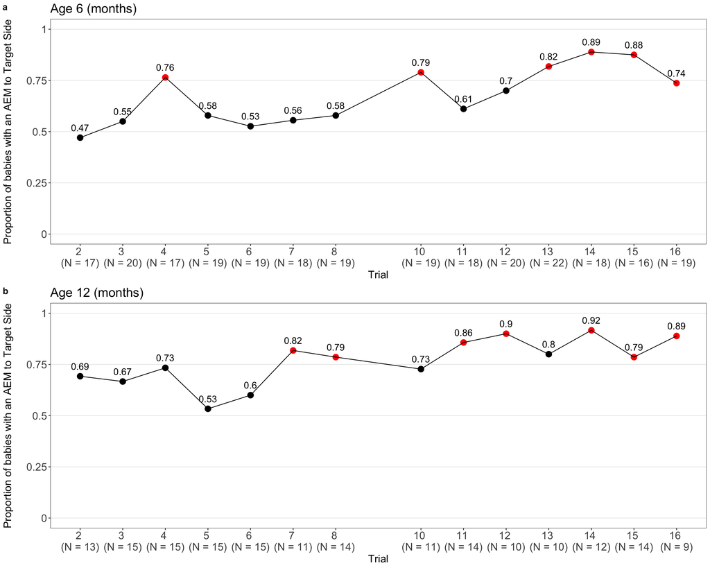

# AV

Note on how outcome was derive:

1. Remove frames coded as “nobabyface”, “noface”, “none”, or “away”
2. Remove “left”, “right” frames with confidence < 85%
3. Use “left” vs “right” to code “target” vs “non-target” depending on the task and version. Calculate % looking for each synch side as:

   % looking = (target) / (target + non-target)

   *left & right frames all need to have >= 85% confidence. A trial must have at least 33% usable data (i.e. left, right frames at 85% confidence) to be included.

## Data count

Number (and percent) of infants who viewed the task at all (2nd column, as % of consented sample with any icatcher data & in frame data , with sufficient usable data (3rd column, as % of infants who viewed the task), with fixation on a single side >80% of the task (4th column, as % of infants with usable data), and final N in the analytic dataset.

```
## # A tibble: 2 × 6
##   Age   Enrolled iCatcher_Ran iCatcher_Good Fixation  Usable
##   <fct> <chr>    <chr>        <chr>         <chr>      <int>
## 1 6     29       29 (100.0%)  27 (93.1%)    4 (14.8%)     23
## 2 12    26       25 (96.2%)   24 (96.0%)    4 (16.7%)     20
```

Video quality metrics by age group. Percentages reflect the mean across trials with iCatcher+ output only, calculated out of frames processed by iCatcher+. Trials where iCatcher+ produced no output are counted as missing trials.

| **Characteristic** | **6** N = 29<sup>1</sup> | **12** N = 25<sup>1</sup> |
| --- | --- | --- |
| max_trial |  |  |
| 4 | 29 (100%) | 25 (100%) |
| No face detected (%) | 1.5 (0.0, 7.0) | 0.2 (0.0, 11.2) |
| Unknown | 0 | 1 |
| Away looks (%) | 11.2 (3.3, 18.8) | 4.8 (1.6, 20.7) |
| Unknown | 0 | 1 |
| Low confidence left & right frames (%) | 10.6 (8.1, 18.0) | 11.9 (8.0, 16.1) |
| Unknown | 0 | 1 |

<sup>1</sup> n (%); Median (Q1, Q3)

**Median (IQR) number of test trials with usable data (final analytic)**

| **Characteristic** | **6** N = 23 | **12** N = 20 |
| --- | --- | --- |
| trial_num |  |  |
| Median (Q1, Q3) | 4.00 (3.00, 4.00) | 4.00 (2.50, 4.00) |
| Min, Max | 1.00, 4.00 | 1.00, 4.00 |

# Word recognition

How outcome was derived:

Example of foot and milk (paired).

The word foot is the target in trial 1 and the distractor at trial 9. the difference for foot = % looking at the word foot in trial 1 - % looking at the word foot in trial 9. Simplified:

foot_diff = trial1_target - trial9_distractor = trial1_target - (1 - trial9_target) = trial1_target + trial9_target - 1

But remember that the words are paired (these pairs are always shown together): foot ~ milk banana ~ hair hand ~ yogurt eyes ~ cookie mouth ~ apple

The word milk then the target at trial 9 but the distractor at trial 1. So then for “milk”: the difference for milk = % looking at the word milk in trial 9 - % looking at the word milk in trial 1. Simplified:

milk_diff = trial9_target – trial1_distractor = trial9_target - (1 - trial1_target) = trial9_target + trial1_target - 1

And then if you look at the math, foot_diff comes out to be the same as milk_diff (trial1_target + trial9_target – 1), so we just use this word-paired data once & we have 5 pairs in total. Kiddos will have up to 5 rows of final difference score.

The same thing repeats for trial 11 and trial 19.

Then the final data for foot ~ milk is: average %target - average %distractor = average of trial1_target & trial11_target - average of trial9_distractor & trial19_distractor.

# Analysis

Number (and percent) of infants who viewed the task at all (2nd column, as % of consented sample with any icatcher data & in frame data , with sufficient usable data (3rd column, as % of infants who viewed the task), with fixation on a single side >80% of the task (4th column, as % of infants with usable data), and final N in the analytic dataset.

```
## # A tibble: 2 × 6
##   Age   Enrolled iCatcher_Ran iCatcher_Good Fixation  Usable
##   <fct> <chr>    <chr>        <chr>         <chr>      <int>
## 1 6     29       29 (100.0%)  27 (93.1%)    4 (14.8%)     23
## 2 12    26       25 (96.2%)   24 (96.0%)    6 (25.0%)     18
```

Video quality metrics by age group. Percentages reflect the mean across trials with iCatcher+ output only, calculated out of frames processed by iCatcher+. Trials where iCatcher+ produced no output are counted as missing trials.

| **Characteristic** | **6** N = 29<sup>1</sup> | **12** N = 25<sup>1</sup> |
| --- | --- | --- |
| max_trial |  |  |
| 20 | 29 (100%) | 25 (100%) |
| No face detected (%) | 1.9 (0.0, 9.1) | 6.8 (0.0, 13.9) |
| Unknown | 0 | 1 |
| Away looks (%) | 20.9 (9.8, 36.5) | 15.1 (5.6, 25.8) |
| Unknown | 0 | 1 |
| Low confidence left & right frames (%) | 10.4 (7.3, 14.3) | 11.5 (8.4, 18.3) |
| Unknown | 0 | 1 |

<sup>1</sup> n (%); Median (Q1, Q3)

**Median (IQR) number of test trials with usable data (final analytic)**

| **Characteristic** | **6** N = 23 | **12** N = 18 |
| --- | --- | --- |
| trial_num |  |  |
| Median (Q1, Q3) | 11.00 (6.00, 14.00) | 9.50 (7.00, 12.00) |
| Min, Max | 1.00, 17.00 | 1.00, 15.00 |

Final word recognition N (lower due to % target or % distractor is not available for the “difference” calculation)

**Median (IQR) number of test trials with usable data (final analytic)**

| **Characteristic** | **6** N = 19 | **12** N = 15 |
| --- | --- | --- |
| n |  |  |
| Median (Q1, Q3) | 2.00 (1.00, 3.00) | 2.00 (1.00, 3.00) |
| Min, Max | 1.00, 3.00 | 1.00, 3.00 |

# Numeracy

4 versions, participants sees ONLY small constant in 2 versions, and ONLY large constant in the other 2 versions.

Note on how outcome was derive:

1. Remove frames coded as “nobabyface”, “noface”, “none”, or “away”
2. Remove “left”, “right” frames with confidence < 85%
3. Use “left” vs “right” to code “target” vs “non-target” depending on the task and version. Calculate % looking for each alternating/changing side as:

   % looking = (target) / (target + non-target)

   *left & right frames all need to have >= 85% confidence. A trial must have at least 33% usable data (i.e. left, right frames at 85% confidence) to be included.

## Data count

Number (and percent) of infants who viewed the task at all (2nd column, as % of consented sample with any icatcher data & in frame data , with sufficient usable data (3rd column, as % of infants who viewed the task), with fixation on a single side >80% of the task (4th column, as % of infants with usable data), and final N in the analytic dataset.

```
## # A tibble: 2 × 6
##   Age   Enrolled iCatcher_Ran iCatcher_Good Fixation  Usable
##   <fct> <chr>    <chr>        <chr>         <chr>      <int>
## 1 6     29       28 (96.6%)   25 (89.3%)    8 (32.0%)     17
## 2 12    26       25 (96.2%)   23 (92.0%)    9 (39.1%)     14
```

Video quality metrics by age group. Percentages reflect the mean across trials with iCatcher+ output only, calculated out of frames processed by iCatcher+. Trials where iCatcher+ produced no output are counted as missing trials.

| **Characteristic** | **6** N = 28<sup>1</sup> | **12** N = 25<sup>1</sup> |
| --- | --- | --- |
| max_trial |  |  |
| 4 | 28 (100%) | 25 (100%) |
| No face detected (%) | 3.6 (0.6, 11.5) | 9.8 (0.0, 17.1) |
| Away looks (%) | 16.4 (7.4, 34.4) | 18.4 (11.1, 23.8) |
| Low confidence left & right frames (%) | 12.1 (8.1, 14.9) | 16.7 (13.7, 19.9) |

<sup>1</sup> n (%); Median (Q1, Q3)

**Median (IQR) number of test trials with usable data (final analytic)**

| **Characteristic** | **6** N = 17 | **12** N = 14 |
| --- | --- | --- |
| trial_num |  |  |
| Median (Q1, Q3) | 4.00 (3.00, 4.00) | 4.00 (2.00, 4.00) |
| Min, Max | 2.00, 4.00 | 1.00, 4.00 |

## Analysis

Without stimulus type due to small sample size in the Large Constant version

```
##        Condition  Estimate (95% CI) P-value
## 1        Overall  0.57 (0.46, 0.67)   0.136
## 2              6  0.54 (0.44, 0.64)   0.383
## 3             12  0.60 (0.50, 0.70)    0.06
## 4 Age 12 - Age 6 0.06 (-0.05, 0.16)   0.257
```

# Helper Hinderer

8 versions, participants sees both helper and hinderer.

Note on how outcome was derive:

1. Remove frames coded as “nobabyface”, “noface”, “none”, or “away”
2. Remove “left”, “right” frames with confidence < 85%
3. Use “left” vs “right” to code “target” vs “non-target” depending on the task and version. Calculate % looking for each helper side as:

   % looking = (target) / (target + non-target)

   *left & right frames all need to have >= 85% confidence. A trial must have at least 33% usable data (i.e. left, right frames at 85% confidence) to be included.

## Data count

Number (and percent) of infants who viewed the task at all (2nd column, as % of consented sample with any icatcher data & in frame data , with sufficient usable data (3rd column, as % of infants who viewed the task), with fixation on a single side >80% of the task (4th column, as % of infants with usable data), and final N in the analytic dataset.

```
## # A tibble: 2 × 6
##   Age   Enrolled iCatcher_Ran iCatcher_Good Fixation  Usable
##   <fct> <chr>    <chr>        <chr>         <chr>      <int>
## 1 6     29       28 (96.6%)   19 (67.9%)    1 (5.3%)      18
## 2 12    26       26 (100.0%)  19 (73.1%)    3 (15.8%)     16
```

Video quality metrics by age group. Percentages reflect the mean across trials with iCatcher+ output only, calculated out of frames processed by iCatcher+. Trials where iCatcher+ produced no output are counted as missing trials.

| **Characteristic** | **6** N = 28<sup>1</sup> | **12** N = 26<sup>1</sup> |
| --- | --- | --- |
| max_trial |  |  |
| 14 | 28 (100%) | 26 (100%) |
| No face detected (%) | 5.2 (1.7, 14.3) | 5.4 (1.9, 16.5) |
| Away looks (%) | 17.8 (13.8, 30.4) | 15.1 (8.4, 23.6) |
| Low confidence left & right frames (%) | 14.6 (11.3, 18.3) | 15.3 (11.9, 20.1) |

<sup>1</sup> n (%); Median (Q1, Q3)

**Median (IQR) number of test trials with usable data (final analytic)**

| **Characteristic** | **6** N = 18 | **12** N = 16 |
| --- | --- | --- |
| trial_num |  |  |
| Median (Q1, Q3) | 2.00 (1.00, 2.00) | 1.50 (1.00, 2.00) |
| Min, Max | 1.00, 2.00 | 1.00, 2.00 |

For each block, a participant was required to have at least one usable helper trial and at least one hinderer trial (Block 1: trials 1–6; Block 2: trials 8–13), where usable trials were defined as having at least 33% of frames with valid iCatcher+ detections at ≥85% confidence.

**Median (IQR) number of test trials with usable data (final analytic)**

| **Characteristic** | **6** N = 17 | **12** N = 16 |
| --- | --- | --- |
| n |  |  |
| Median (Q1, Q3) | 2.00 (1.00, 2.00) | 1.50 (1.00, 2.00) |
| Min, Max | 1.00, 2.00 | 1.00, 2.00 |

# Figures

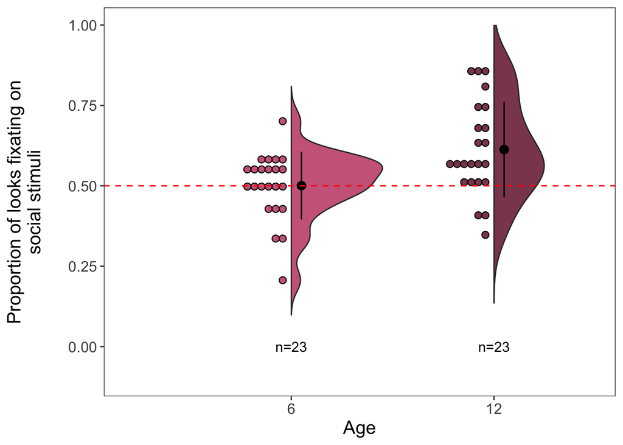

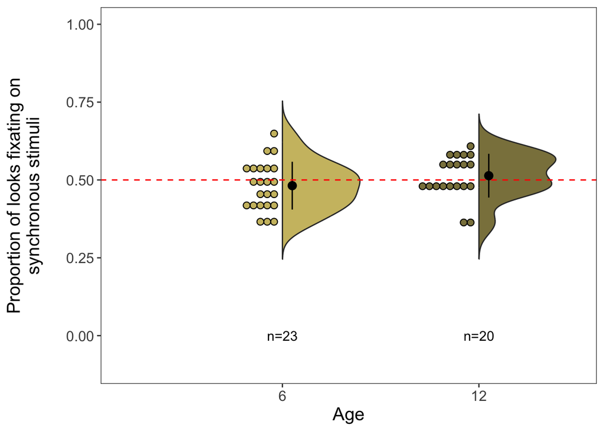

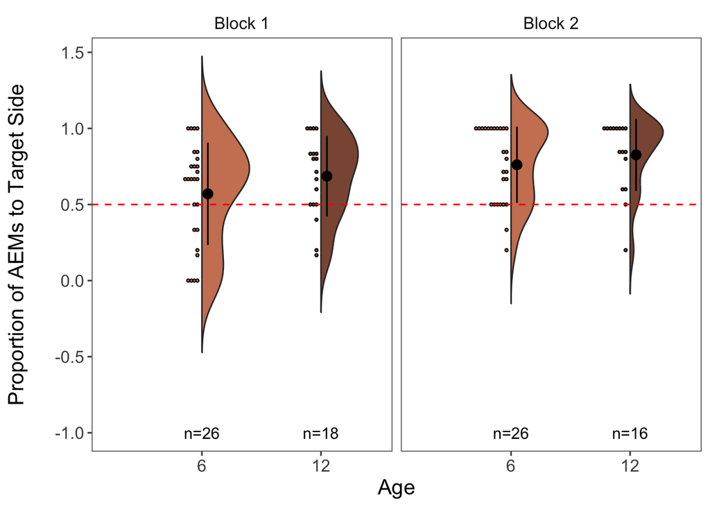

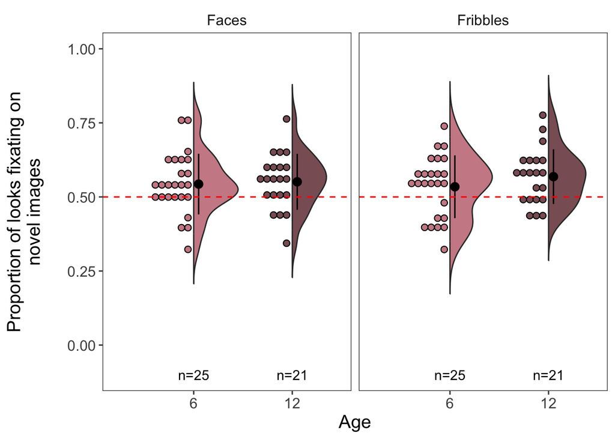

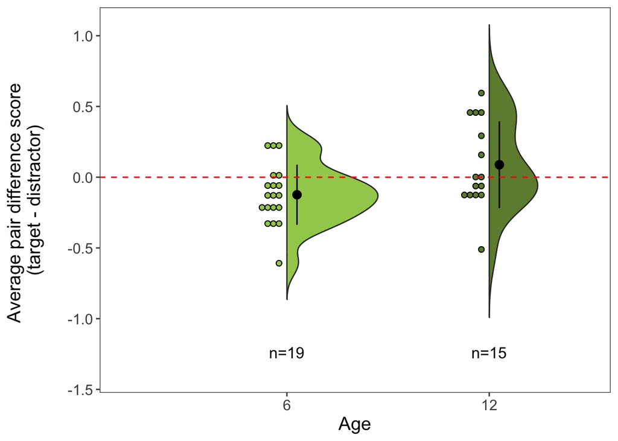

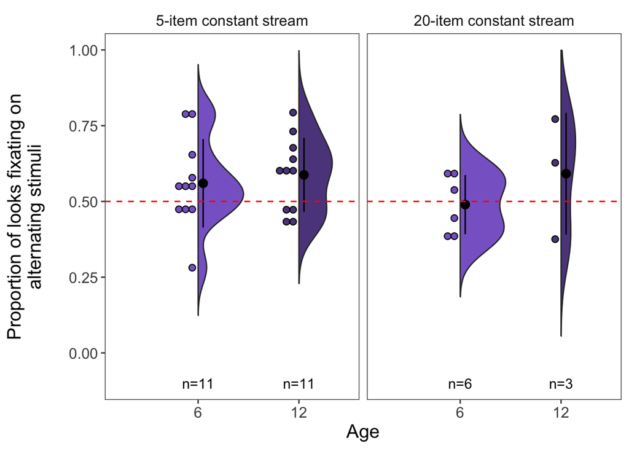

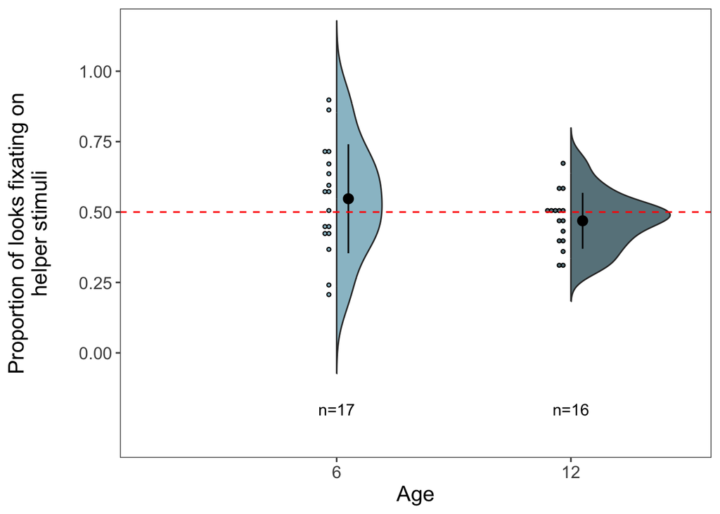

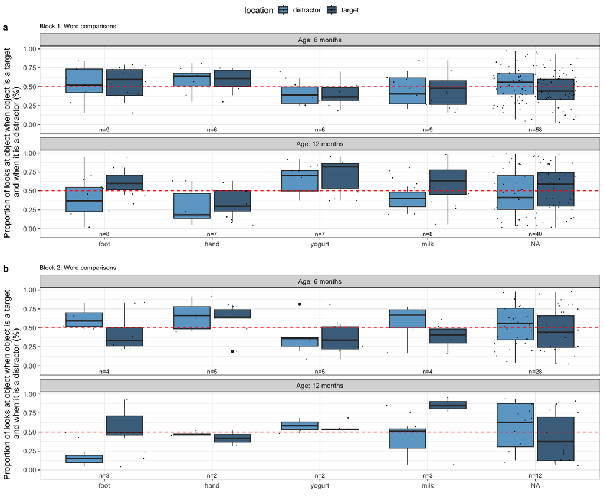

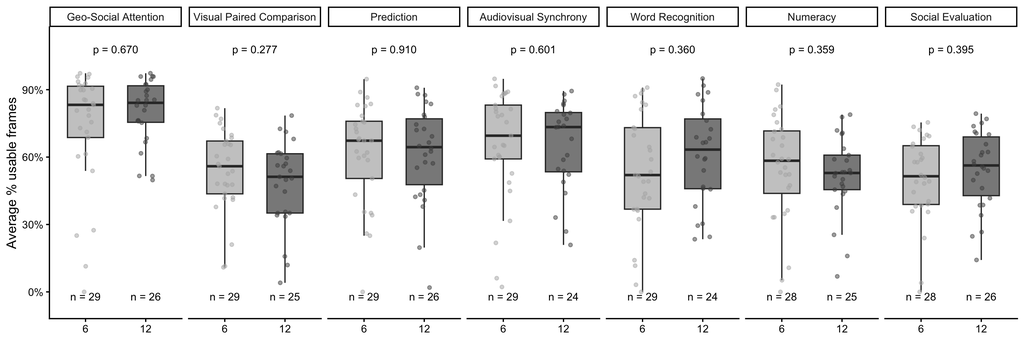

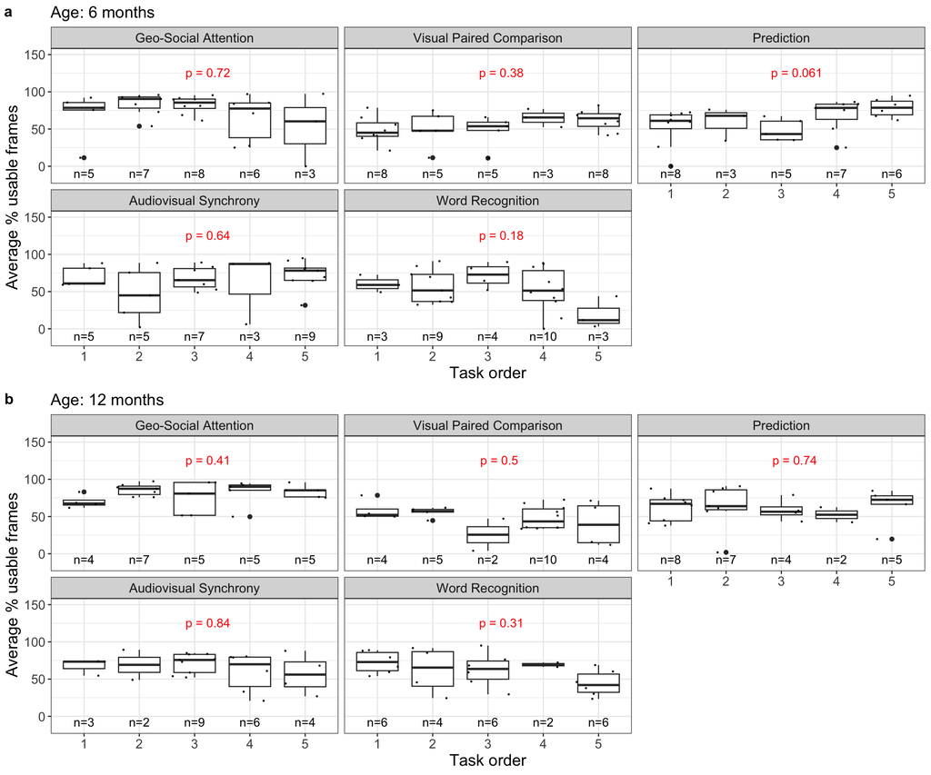

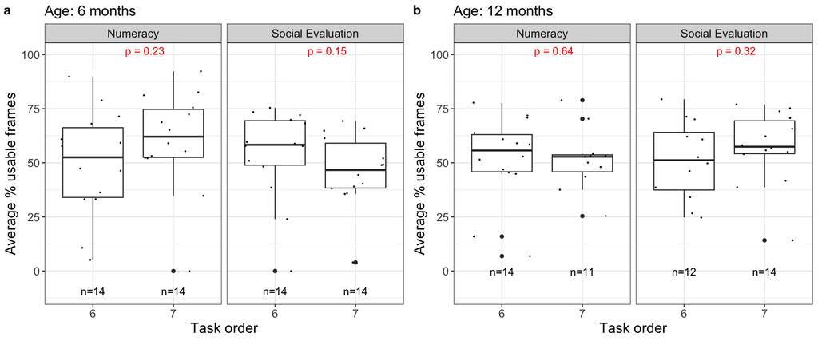

# Final Tables

Table 3: Data quality metrics from iCatcher+ output across all administered trials.

| Task | N trials (QC) | N valid iCatcher+ (6) | N valid iCatcher+ (12) | N 0% completion (6) | N 0% completion (12) | Median (IQR) % no-face frames (6) | Median (IQR) % no-face frames (12) | Median (IQR) % away frames (6) | Median (IQR) % away frames (12) | Median (IQR) % low-confidence frames (6) | Median (IQR) % low-confidence frames (12) |
| --- | --- | --- | --- | --- | --- | --- | --- | --- | --- | --- | --- |
| Geo-Social Attention | 10 | 29 (100.0%) | 26 (100.0%) | 0 (0.0%) | 0 (0.0%) | 0.0 (0.0, 0.0) | 0.0 (0.0, 3.9) | 2.7 (0.0, 10.0) | 0.8 (0.0, 5.0) | 9.8 (5.1, 14.8) | 8.8 (6.6, 15.0) |
| Visual Paired Comparison (VPC) | 12 | 29 (100.0%) | 25 (96.2%) | 0 (0.0%) | 0 (0.0%) | 3.6 (0.6, 8.4) | 7.1 (4.9, 20.1) | 25.0 (16.8, 31.4) | 18.8 (11.0, 29.3) | 11.8 (8.8, 16.0) | 14.2 (11.4, 17.7) |
| Prediction | 16 | 29 (100.0%) | 26 (100.0%) | 0 (0.0%) | 0 (0.0%) | 0.0 (0.0, 0.0) | 0.2 (0.0, 8.2) | 8.7 (1.9, 15.9) | 2.4 (0.5, 9.8) | 17.8 (11.5, 26.4) | 18.5 (11.1, 26.4) |
| Audiovisual Synchrony | 4 | 29 (100.0%) | 25 (96.2%) | 0 (0.0%) | 1 (4.0%) | 1.5 (0.0, 7.0) | 0.2 (0.0, 11.2) | 11.2 (3.3, 18.8) | 4.8 (1.6, 20.7) | 10.6 (8.1, 18.0) | 11.9 (8.0, 16.1) |
| Word Comprehension | 20 | 29 (100.0%) | 25 (96.2%) | 0 (0.0%) | 1 (4.0%) | 1.9 (0.0, 9.1) | 6.8 (0.0, 13.9) | 20.9 (9.8, 36.5) | 15.1 (5.6, 25.8) | 10.4 (7.3, 14.3) | 11.5 (8.4, 18.3) |
| Numeracy | 4 | 28 (96.6%) | 25 (96.2%) | 0 (0.0%) | 0 (0.0%) | 3.6 (0.6, 11.5) | 9.8 (0.0, 17.1) | 16.4 (7.4, 34.4) | 18.4 (11.1, 23.8) | 12.1 (8.1, 14.9) | 16.7 (13.7, 19.9) |
| Social Evaluation | 14 | 28 (96.6%) | 26 (100.0%) | 0 (0.0%) | 0 (0.0%) | 5.2 (1.7, 14.3) | 5.4 (1.9, 16.5) | 17.8 (13.8, 30.4) | 15.1 (8.4, 23.6) | 14.6 (11.3, 18.3) | 15.3 (11.9, 20.1) |

Table 4: Participant retention across data quality and inclusion criteria steps, by task and age group.

| Task | Analytic trials/word pairs | N valid iCatcher+ (6) | N valid iCatcher+ (12) | N ≥33% usable frames (6) | N ≥33% usable frames (12) | N side bias (6) | N side bias (12) | N final analytic sample (6) | N final analytic sample (12) | Median (IQR) trials (6) | Median (IQR) trials (12) |
| --- | --- | --- | --- | --- | --- | --- | --- | --- | --- | --- | --- |
| Geo-Social Attention | 10 | 29 (100.0%) | 26 (100.0%) | 28 (96.6%) | 26 (100.0%) | 5 (17.9%) | 3 (11.5%) | 23 | 23 | 8.0 (7.0, 9.0) | 7.0 (5.0, 9.0) |
| Visual Paired Comparison | 6 | 29 (100.0%) | 25 (96.2%) | 27 (93.1%) | 23 (92.0%) | 2 (7.4%) | 1 (4.3%) | 25 | 22 | 6.0 (5.0, 6.0) | 5.0 (4.2, 6.0) |
| Prediction | 14 | 29 (100.0%) | 26 (100.0%) | 28 (96.6%) | 25 (96.2%) | — | — | 26 | 18 | 10.5 (9.0, 12.0) | 10.0 (8.2, 11.8) |
| Audiovisual Synchrony | 4 | 29 (100.0%) | 25 (96.2%) | 27 (93.1%) | 24 (96.0%) | 4 (14.8%) | 4 (16.7%) | 23 | 20 | 4.0 (3.0, 4.0) | 4.0 (2.8, 4.0) |
| Word Comprehension | 5 | 29 (100.0%) | 25 (96.2%) | 27 (93.1%) | 24 (96.0%) | 4 (14.8%) | 6 (25.0%) | 19 | 15 | 2.0 (1.0, 3.0) | 2.0 (1.5, 3.0) |
| Numeracy | 4 | 28 (96.6%) | 25 (96.2%) | 25 (89.3%) | 23 (92.0%) | 8 (32.0%) | 9 (39.1%) | 17 | 14 | 4.0 (3.0, 4.0) | 4.0 (2.2, 4.0) |
| Social Evaluation | 2 | 28 (96.6%) | 26 (100.0%) | 19 (67.9%) | 19 (73.1%) | 1 (5.3%) | 3 (15.8%) | 17 | 16 | 2.0 (1.0, 2.0) | 1.5 (1.0, 2.0) |

Summary of mixed model estimates

| Task | Overall Estimate (95% CI) | Overall P-value | Age 6 Estimate (95% CI) | Age 6 P-value | Age 12 Estimate (95% CI) | Age 12 P-value | Age 12 - Age 6 Estimate (95% CI) | Age 12 - Age 6 P-value |
| --- | --- | --- | --- | --- | --- | --- | --- | --- |
| Geo-Social Attention | 0.56 (0.51, 0.61) | 0.019 | 0.50 (0.44, 0.56) | 0.921 | 0.62 (0.56, 0.68) | < 0.001 | 0.11 (0.04, 0.19) | 0.003 |
| VPC Social (face) | 0.54 (0.51, 0.58) | 0.014 | 0.54 (0.50, 0.58) | 0.064 | 0.55 (0.51, 0.60) | 0.028 | 0.01 (-0.04, 0.07) | 0.659 |
| VPC Non-social (fribbles) | 0.55 (0.51, 0.58) | 0.009 | 0.54 (0.50, 0.58) | 0.067 | 0.56 (0.51, 0.60) | 0.013 | 0.02 (-0.04, 0.08) | 0.5 |
| Prediction Block 1 | 0.63 (0.54, 0.71) | 0.004 | 0.57 (0.46, 0.68) | 0.206 | 0.69 (0.55, 0.82) | 0.006 | 0.12 (-0.05, 0.29) | 0.181 |
| Prediction Block 2 | 0.79 (0.71, 0.88) | < 0.001 | 0.76 (0.65, 0.87) | < 0.001 | 0.83 (0.69, 0.97) | < 0.001 | 0.07 (-0.11, 0.24) | 0.465 |
| AV Synchrony | 0.49 (0.44, 0.55) | 0.767 | 0.48 (0.43, 0.54) | 0.441 | 0.51 (0.45, 0.57) | 0.78 | 0.03 (-0.04, 0.10) | 0.454 |
| Word comprehension | 0.06 (-0.59, 0.72) | 0.461 | -0.05 (-0.29, 0.20) | 0.582 | 0.17 (-0.06, 0.41) | 0.105 | 0.22 (0.01, 0.43) | 0.042 |
| Numeracy 5-item stream constant | 0.58 (0.48, 0.67) | 0.105 | 0.56 (0.46, 0.67) | 0.197 | 0.59 (0.48, 0.69) | 0.104 | 0.02 (-0.10, 0.14) | 0.717 |
| Numeracy 20-item stream constant | 0.56 (0.44, 0.68) | 0.304 | 0.48 (0.35, 0.61) | 0.795 | 0.63 (0.46, 0.80) | 0.124 | 0.15 (-0.05, 0.35) | 0.143 |
| Social Evaluation | 0.51 (0.46, 0.57) | 0.658 | 0.56 (0.48, 0.63) | 0.14 | 0.47 (0.39, 0.55) | 0.408 | -0.09 (-0.20, 0.02) | 0.108 |